# SNA

# SNA (via Newman)

I’ll be adding to this as I get further into the Newman Text.

# Chapter 6

## Adjacency Matrices

Networks are represented in adjacency matrices. These are matrices (A) of values wherein A(i,j) = 1 if there is an edge between i and j and 0 otherwise.

```r
A = c(0,1,0,0,1,0,1,0,1,1,0,0,0,1,0,1,1,1,0,1,1,0,0,0,1,0,1,0,0,0,0,0,1,0,0,0) # Matrix 6.2 in Newman
A = matrix(A, 6,6)
colnames(A) = c("Bill", "Ted", "Jane", "Sally", "Mark", "Marsha") # I like to have names to make this easier.
rownames(A) = c("Bill", "Ted", "Jane", "Sally", "Mark", "Marsha")
A
```

```
##        Bill Ted Jane Sally Mark Marsha
## Bill      0   1    0     0    1      0
## Ted       1   0    1     1    0      0
## Jane      0   1    0     1    1      1
## Sally     0   1    1     0    0      0
## Mark      1   0    1     0    0      0
## Marsha    0   0    1     0    0      0
```

This matrix represents an undirected graph. It’s graphical representation can be seen below:

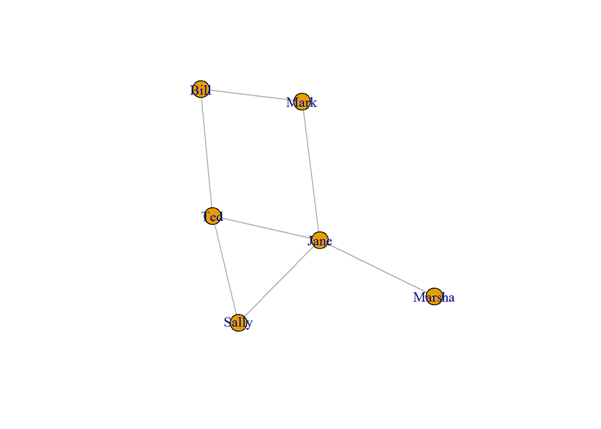

```r
library(igraph)
g = graph.adjacency(A, mode='undirected')
plot(g, show.arrows=F)
```

```r
dirA = c(0,0,0,1,0,0,0,0,1,0,0,0,1,0,0,0,1,0,0,0,0,0,0,1,0,0,0,1,0,1,0,1,0,0,0,0) # Matrix 6.6 in Newman (directed)
dirA = matrix(dirA, 6, 6)
colnames(dirA) = c("Bill", "Ted", "Jane", "Sally", "Mark", "Marsha") # I like to have names to make this easier.
rownames(dirA) = c("Bill", "Ted", "Jane", "Sally", "Mark", "Marsha")
dirA
```

```
##        Bill Ted Jane Sally Mark Marsha
## Bill      0   0    1     0    0      0
## Ted       0   0    0     0    0      1
## Jane      0   1    0     0    0      0
## Sally     1   0    0     0    1      0
## Mark      0   0    1     0    0      0
## Marsha    0   0    0     1    1      0
```

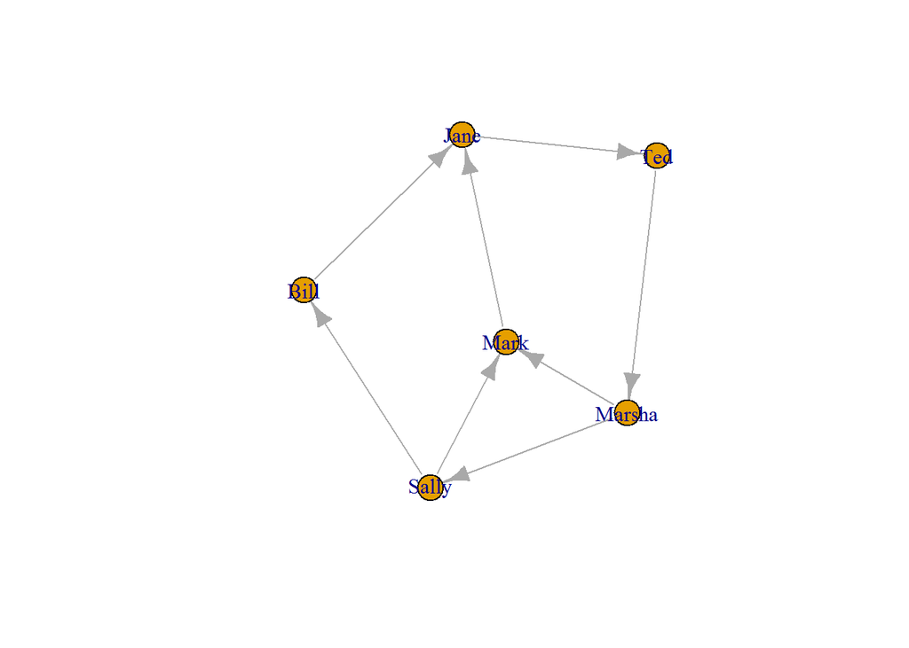

```r
c = graph.adjacency(dirA)
plot(c)
```

#### Cocitation Networks

It is helpful to turn a directed newtork into an undirected one because there are more analytical methods for undirected than directed networks. One method for doing this is the cocitation network. The cocitation of two vertices i and j in a directed network is the number of vertices that have outgoing edges pointing to both i and j.

```r
dirA = c(0,0,0,1,0,0,0,0,1,0,0,0,1,0,0,0,1,0,0,0,0,0,0,1,0,0,0,1,0,1,0,1,0,0,0,0) # Matrix 6.6 in Newman (directed)
dirA = matrix(dirA, 6, 6)
colnames(dirA) = c("Bill", "Ted", "Jane", "Sally", "Mark", "Marsha") # I like to have names to make this easier.
rownames(dirA) = c("Bill", "Ted", "Jane", "Sally", "Mark", "Marsha")
cocitation = function(mat) { # Formula 6.8 in Newman.
  C = mat %*% t(mat)
  return(C)
}


new = cocitation(dirA)
new
```

```
##        Bill Ted Jane Sally Mark Marsha
## Bill      1   0    0     0    1      0
## Ted       0   1    0     0    0      0
## Jane      0   0    1     0    0      0
## Sally     0   0    0     2    0      1
## Mark      1   0    0     0    1      0
## Marsha    0   0    0     1    0      2
```

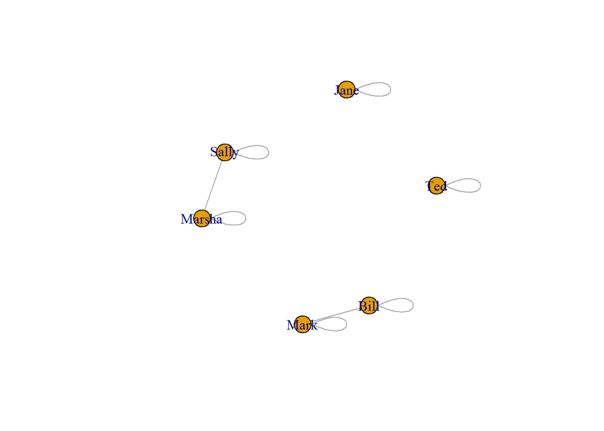

```r
g = graph.adjacency(new, weighted=T, mode="undirected")
plot(g)
```

#### Bibliographic Coupling

The bibliographic coupliing of two vertices in a directed network is the number of other vertices to which both point.

```r
bibCoupling = function(mat) { # Newman 6.11
  B = t(mat) %*% mat
  return(B)
}

new = bibCoupling(dirA)
new
```

```
##        Bill Ted Jane Sally Mark Marsha
## Bill      1   0    0     0    1      0
## Ted       0   1    0     0    0      0
## Jane      0   0    2     0    0      0
## Sally     0   0    0     1    1      0
## Mark      1   0    0     1    2      0
## Marsha    0   0    0     0    0      1
```

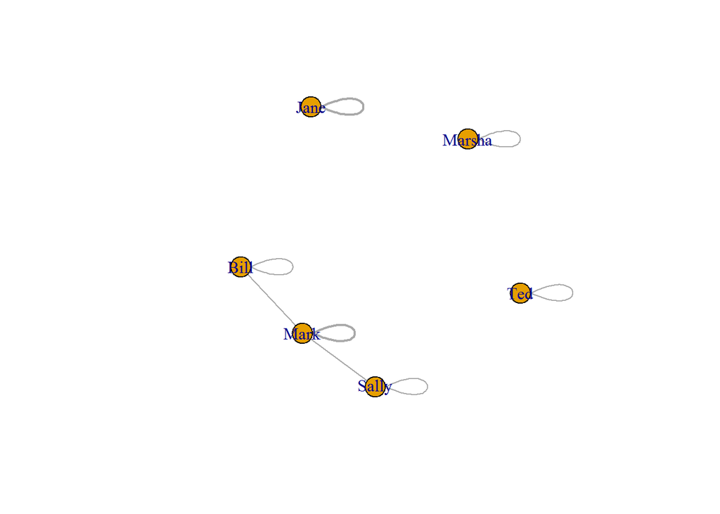

```r
g = graph.adjacency(new, weighted=T, mode="undirected")
plot(g, edge.width=E(g)$weight)
```

## Bipartite Networks

It’s helpful, especially in authorship networks, to have a network in which nodes are connected through a shared node (like co-authors being connected by a book). This, however, makes analysis more complex, so it is necessary to project the network into a one-mode network. Bipartite networks are represented by incidence matrices of irregular dimensions.

```r
B = c(1,0,0,1,0,1,1,1,1,0,0,1,1,0,1,0,0,1,1,1)
B = matrix(B, byrow = T, 4,5)  # Matrix 6.16 in Newman
colnames(B) = c(1,2,3,4,5)
rownames(B) = c("A", "B", "C", "D")

B
```

```
##   1 2 3 4 5
## A 1 0 0 1 0
## B 1 1 1 1 0
## C 0 1 1 0 1
## D 0 0 1 1 1
```

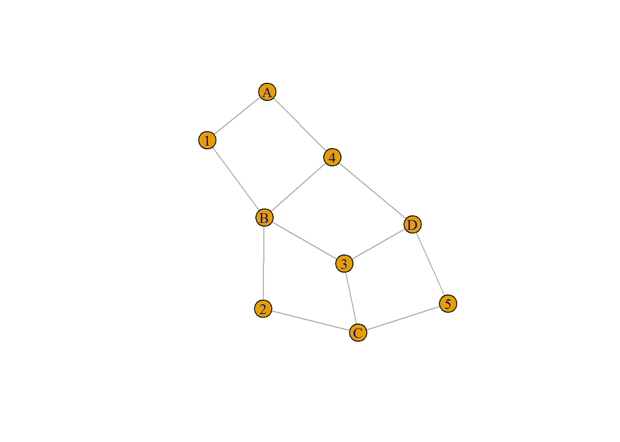

```r
g = graph.incidence(B)
plot(g)
```

The first kind of projection links the entities (1-5) and weights them based on the number of groups (A-D) they are both members of.

```r
B = c(1,0,0,1,0,1,1,1,1,0,0,1,1,0,1,0,0,1,1,1)
B = matrix(B, byrow = T, 4,5)  # Matrix 6.16 in Newman
colnames(B) = c(1,2,3,4,5)
rownames(B) = c("A", "B", "C", "D")

# Newman p. 126
P = t(B) %*% B # Converts the matrix into something similar to an adjacency matrix. Pij is the number of groups to which both i and j belong.
diag(P) = 0 # Set the diagonal elements to 0 to convert P into an adjacency matrix.
P
```

```
##   1 2 3 4 5
## 1 0 1 1 2 0
## 2 1 0 2 1 1
## 3 1 2 0 2 2
## 4 2 1 2 0 1
## 5 0 1 2 1 0
```

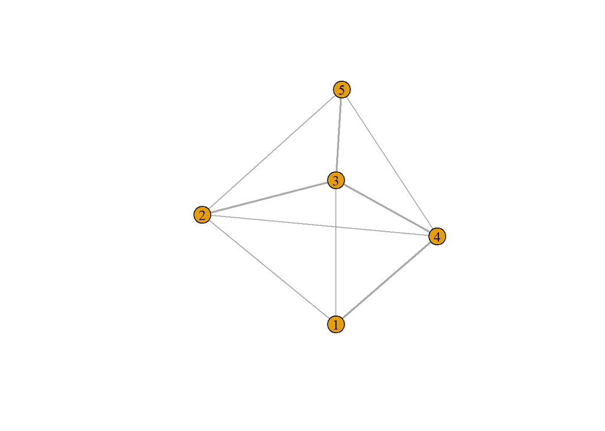

```r
g = graph.adjacency(P, mode='undirected', weighted=T)
plot(g, edge.width=E(g)$weight)
```

The next projection connects the groups (A-D) based on the number of entities (1-5) that they share.

```r
B = c(1,0,0,1,0,1,1,1,1,0,0,1,1,0,1,0,0,1,1,1)
B = matrix(B, byrow = T, 4,5)  # Matrix 6.16 in Newman
colnames(B) = c(1,2,3,4,5)
rownames(B) = c("A", "B", "C", "D")

# Newman p. 126
Pp = B %*% t(B) # Project to an adjacency matrix.
Pp # The diagonals here represent the number of members of each group.
```

```
##   A B C D
## A 2 2 0 1
## B 2 4 2 2
## C 0 2 3 2
## D 1 2 2 3
```

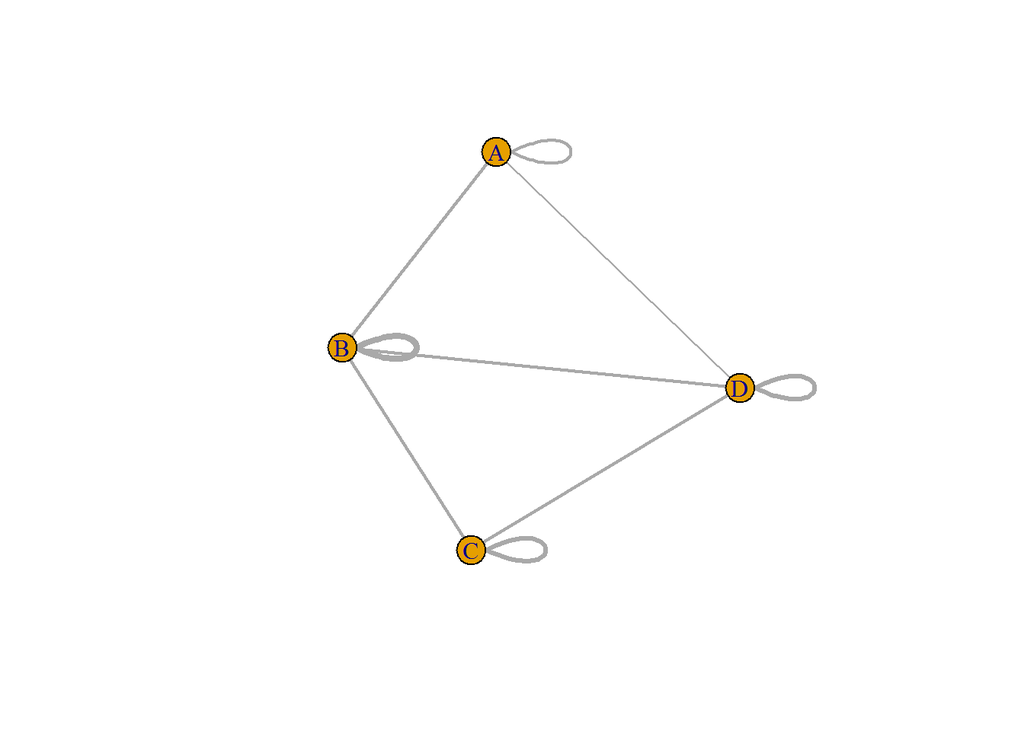

```r
g = graph.adjacency(Pp, mode='undirected', weighted=T)
plot(g, edge.width=E(g)$weight)
```

## Degree Measures

The degree of a vertex is the number of edges connected to it.

```r
B = c(1,0,0,1,0,1,1,1,1,0,0,1,1,0,1,0,0,1,1,1)
B = matrix(B, byrow = T, 4,5)  # Matrix 6.16 in Newman
colnames(B) = c(1,2,3,4,5)
rownames(B) = c("A", "B", "C", "D")

degree = function(mat, index) { # Newman 6.19
  return(sum(mat[index,]))
}

B
```

```
##   1 2 3 4 5
## A 1 0 0 1 0
## B 1 1 1 1 0
## C 0 1 1 0 1
## D 0 0 1 1 1
```

```r
degree(B, 'B') # How many edges are connected to 'B' in the network. Also equivalent to the diagonal value in Pp.
```

```
## [1] 4
```

```r
Pp['B','B']
```

```
## [1] 4
```

```r
# Switching to a simpler matrix
A = c(0,1,0,0,1,0,1,0,1,1,0,0,0,1,0,1,1,1,0,1,1,0,0,0,1,0,1,0,0,0,0,0,1,0,0,0) # Matrix 6.2 in Newman
A = matrix(A, 6,6)
colnames(A) = c("Bill", "Ted", "Jane", "Sally", "Mark", "Marsha") # I like to have names to make this easier.
rownames(A) = c("Bill", "Ted", "Jane", "Sally", "Mark", "Marsha")

# Number of edge ends, 6.20
m2 = sum(A)
m2
```

```
## [1] 14
```

```r
# Mean Degree, 6.23
c = m2 / length(A[1,])
c
```

```
## [1] 2.333333
```

### Density

The density or connectedness of a graph can be determined by taking the fraction of the mean connections over the number of possible connections.

```r
A = c(0,1,0,0,1,0,1,0,1,1,0,0,0,1,0,1,1,1,0,1,1,0,0,0,1,0,1,0,0,0,0,0,1,0,0,0) # Matrix 6.2 in Newman
A = matrix(A, 6,6)
colnames(A) = c("Bill", "Ted", "Jane", "Sally", "Mark", "Marsha") # I like to have names to make this easier.
rownames(A) = c("Bill", "Ted", "Jane", "Sally", "Mark", "Marsha")

# Number of edge ends, 6.20
m2 = sum(A)

# Mean Degree, 6.23
c = m2 / ncol(A)

# Density, 6.24
c / (ncol(A) - 1)
```

```
## [1] 0.4666667
```

### Directed Networks

Determining degree in directed networks is more complex because each vertex will have an in degree and an out degree.

```r
# In-degree, 6.25 (a) where i = 'Marsha'
kin = sum(dirA['Marsha',])
kin
```

```
## [1] 2
```

```r
# Out-degree. 6.25 (b) where j = 'Marsha'
kout = sum(dirA[,'Marsha'])
kout
```

```
## [1] 1
```

We also need different measures for determining the number of edges in a directed networks. The number of edges is determined by counting the number of incoming connections.

```r
dirA = c(0,0,0,1,0,0,0,0,1,0,0,0,1,0,0,0,1,0,0,0,0,0,0,1,0,0,0,1,0,1,0,1,0,0,0,0) # Matrix 6.6 in Newman (directed)
dirA = matrix(dirA, 6, 6)
colnames(dirA) = c("Bill", "Ted", "Jane", "Sally", "Mark", "Marsha") # I like to have names to make this easier.
rownames(dirA) = c("Bill", "Ted", "Jane", "Sally", "Mark", "Marsha")

numDirEdges = function(mat) { #6.26
   m = 0
   for(i in 1:length(mat[,1])){ # iterate over rows
    m = m + sum(dirA[i,])
   }
   return(m)
}
m = numDirEdges(dirA)
m
```

```
## [1] 8
```

```r
# Mean Degree, 6.28
c = m / length(dirA[1,])
c
```

```
## [1] 1.333333
```

## Paths

A path is any sequence of vertices such that every consecutive pair of vertices in the sequence is connected by an edge in the network. We can measure the total number of paths of a given length:

```r
library(expm)
A = c(0,1,0,0,1,0,1,0,1,1,0,0,0,1,0,1,1,1,0,1,1,0,0,0,1,0,1,0,0,0,0,0,1,0,0,0) # Matrix 6.2 in Newman
A = matrix(A, 6,6)
colnames(A) = c("Bill", "Ted", "Jane", "Sally", "Mark", "Marsha") # I like to have names to make this easier.
rownames(A) = c("Bill", "Ted", "Jane", "Sally", "Mark", "Marsha")

numPaths = function(A, len){ # 6.31
  N = 0
  for(i in 1:len) {
    A = A %*% A
  }
  for(i in 1:length(A[,1])) {
    for(j in 1:length(A[1,])) {
      if(A[i,j] == len){
        N = N+1
      }
    }
  }
  return(N)
}
N = numPaths(A, 2)

# Finding the number of loops, 6.32
numLoops = function(A, len){
  return(sum(diag(A %^% len)))
}
L = numLoops(A, 3)
L
```

```
## [1] 6
```

```r
# Using eigenvalues to find number of loops, 6.33
numLoops = function(A, len){
  k = eigen(A)$values
  L = sum(k^len)
  return(L)
}
L = numLoops(A, 3)
L
```

```
## [1] 6
```

### Geodesic Path (distance)

The Geodesic distance is the minimum number of paths between two nodes in a network.

```r
#Newman p. 139.
library(expm)
geodesic = function(A, i, j) {
  done = FALSE
  count = 1

  while (done == F) {
    aij = A %^% count
    if(aij[i,j] > 0) {
      return(count)
    }
    count = count + 1
  }
}
geodesic(A, 2, 5)
```

```
## [1] 2
```

### Random Walks

```r
ranWalk = function(A, n1, steps) { # Newman section 6.14
  P = c()
  for(i in 1:nrow(A)){
    P[i] = degree(A,i) / sum(A)
  }
  walk = c()

  for(i in n1:steps){ # i is number of steps we're on now.

   for(j in 1:nrow(A)) { # Node we're on now.
     prob = c()
     for(k in 1:nrow(A)) { # find next node.
       prob[k] = A[j,k]/degree(A,k) * P[k-1]
       #browser()
     }
     #browser()
     walk[j] = row.names(A)[which.max(prob)]
   }
  }

  return(walk)
}

walk = ranWalk(A, 2, 4)
walk
```

```
## [1] "Mark"  "Sally" "Sally" "Jane"  "Jane"  "Jane"
```

# Chapter 7

## Centrality

Centrality provides a measure of how important a given node is to the network structure and can enable us to find the most important nodes.

### Degree Centrality

Degree centrality is the simplest method of calculating centrality and just uses the degree measure above to determine a node’s importance. The basic premise is that a node with a lot of connections must be important to the network.

```r
A = c(0,1,0,0,1,0,1,0,1,1,0,0,0,1,0,1,1,1,0,1,1,0,0,0,1,0,1,0,0,0,0,0,1,0,0,0) # Matrix 6.2 in Newman
A = matrix(A, 6,6)
colnames(A) = c("Bill", "Ted", "Jane", "Sally", "Mark", "Marsha") # I like to have names to make this easier.
rownames(A) = c("Bill", "Ted", "Jane", "Sally", "Mark", "Marsha")

degreeCent = function(A) { # Section 7.2
  cents = c()
  for(i in 1:nrow(A)){
    cents[i] = degree(A, i)
    names(cents)[i] = row.names(A)[i]
  }
  return(cents)
}

D = degreeCent(A)
D
```

```
##   Bill    Ted   Jane  Sally   Mark Marsha
##      2      3      4      2      2      1
```

### Eigenvector Centrality

Eigenvector centrality “gives each vertex a score proportional to the sum of the scores of its neighbors” (Newman 169).

```r
A = c(0,1,0,0,1,0,1,0,1,1,0,0,0,1,0,1,1,1,0,1,1,0,0,0,1,0,1,0,0,0,0,0,1,0,0,0) # Matrix 6.2 in Newman
A = matrix(A, 6,6)
colnames(A) = c("Bill", "Ted", "Jane", "Sally", "Mark", "Marsha") # I like to have names to make this easier.
rownames(A) = c("Bill", "Ted", "Jane", "Sally", "Mark", "Marsha")

eigenCent = function(A, iter) { # Equation 7.6 in Newman
  x = rep(1, nrow(A))
  for(i in 1:iter) {
    x = A %*% x
  }
  return(x/max(x))
}

E = eigenCent(A, 200)
E
```

```
##             [,1]
## Bill   0.5730455
## Ted    0.8841533
## Jane   1.0000000
## Sally  0.7249330
## Mark   0.6052334
## Marsha 0.3847527
```

Eigenvector centrality doesn’t work as well for directed networks because it penalizes those vertices that only have outgoing connections (by setting them to zero).

### Katz Centrality

Katz centrality corrects for this by giving each vertex some centrality for free.

```r
dirA = c(0,0,0,1,0,0,0,0,1,0,0,0,1,0,0,0,1,0,0,0,0,0,0,1,0,0,0,1,0,1,0,1,0,0,0,0) # Matrix 6.6 in Newman (directed)
dirA = matrix(dirA, 6, 6)
colnames(dirA) = c("Bill", "Ted", "Jane", "Sally", "Mark", "Marsha") # I like to have names to make this easier.
rownames(dirA) = c("Bill", "Ted", "Jane", "Sally", "Mark", "Marsha")

katz = function(A, k=0) { # 7.12 (7.9) in Newman
  if(k == 0){
    k = max(as.numeric(eigen(A)$values))  # Directed graphs give complex number values.
  }
  alpha = 1/k - .05 # Slightly less than 1/max eigenvalue
  B = rep(1, nrow(A))
  x = rep(0, nrow(A)) #start with initial bad estimate of centrality
  for(i in 1:ncol(A)) {
    x = alpha*(A %*% x) + B
  }
  return(x)
}

x = katz(dirA)
x
```

```
##            [,1]
## Bill   3.948322
## Ted    5.600885
## Jane   4.650678
## Sally  5.858336
## Mark   3.948322
## Marsha 7.107051
```

### PageRank

Katz centrality shares the centrality love: if a vertex with high Katz centrality has edges pointing to many others, then those others also get high centrality. PageRank accounts for this by making the centrality that each vertex derives from its network neighbors proportional to their centrality divided by their out degree (175).

```r
dirA = c(0,0,0,1,0,0,0,0,1,0,0,0,1,0,0,0,1,0,0,0,0,0,0,1,0,0,0,1,0,1,0,1,0,0,0,0) # Matrix 6.6 in Newman (directed)
dirA = matrix(dirA, 6, 6)
colnames(dirA) = c("Bill", "Ted", "Jane", "Sally", "Mark", "Marsha") # I like to have names to make this easier.
rownames(dirA) = c("Bill", "Ted", "Jane", "Sally", "Mark", "Marsha")

pageRank = function(A) { # Eq. 7.17 in Newman
  D = diag(degreeCent(A))
  alpha = 1/(max(as.numeric(eigen(A)$values)) - .05)
  B = rep(1, nrow(A))
  x = D%*%solve(D-(alpha * A))%*%B
  row.names(x) = row.names(A)
  return(x)
}

x = pageRank(dirA)
x
```

```
##            [,1]
## Bill   4.936070
## Ted    4.614114
## Jane   4.790859
## Sally  9.110743
## Mark   4.936070
## Marsha 8.797969
```

### Hubs and Authorities

Authorities are nodes that contain useful information on a topic of interest; hubs are nodes that tell us where the best authorities are to be found (Newman 179).

#### The HITS Algorithm

The HITS algorithm gives each vertex i in a network an authority centrality xi and a hub centrality yi. The defining characteristic of a vertex with high authority centrality is that it is pointed to by many hubs and the defining characteristic of a vertex with high hub centrality is that it points to many vertices with high authority centrality (Newman 178-179).

```r
dirA = c(0,0,0,1,0,0,0,0,1,0,0,0,1,0,0,0,1,0,0,0,0,0,0,1,0,0,0,1,0,1,0,1,0,0,0,0) # Matrix 6.6 in Newman (directed)
dirA = matrix(dirA, 6, 6)
colnames(dirA) = c("Bill", "Ted", "Jane", "Sally", "Mark", "Marsha") # I like to have names to make this easier.
rownames(dirA) = c("Bill", "Ted", "Jane", "Sally", "Mark", "Marsha")

hits = function(A) { # Based on the text of Newman 180-181 and ~7.24.
  # x = rep(1, ncol(A))
  # names(x) = colnames(A)
  # y = rep(1, ncol(A))
  # names(y) = colnames(A)
  # x = eigen(A %*% t(A))$vectors[,1] * x
  # y = t(A) %*% x
  # d = cbind(x, y)
  # colnames(d) = c("x", "y")
  x = eigenCent(A %*% t(A), 50)
  y = eigenCent(t(A) %*% A, 50)
  d = cbind(x,y)
  return(d)
}

hits(dirA)
```

```
##                [,1]         [,2]
## Bill   1.568329e-09 5.000000e-01
## Ted    1.392956e-24 1.044717e-24
## Jane   1.392956e-24 1.176246e-09
## Sally  1.000000e+00 5.000000e-01
## Mark   1.568329e-09 1.000000e+00
## Marsha 1.000000e+00 1.044717e-24
```

### Closeness Centrality

Closeness centrality measures the mean distance from a vertex to other vertices (181). Closeness centrality is different than other measures of centrality because it accords low scores for those nodes that are closest to lots of nodes (greater centrality means lower scores). To correct for this, we’ll take the inverse of the closeness measure.

```r
closeness = function(A) { # 7.29
  C = c()
  n = nrow(A)
  for(i in 1:nrow(A)) {
    dist = 0
    for(j in 1:ncol(A)) {
      dist = dist + geodesic(A,i,j)
    }
    C[i] = n / dist
  }
  names(C) = row.names(A)
  return(C)
}

closeness(A)
```

```
##      Bill       Ted      Jane     Sally      Mark    Marsha
## 0.5454545 0.6666667 0.7500000 0.6000000 0.6000000 0.5000000
```

### Betweenness Centrality

Betweenness centrality measures the extent to which a vertex lies on paths between other vertices (185). Betweenness centrality can be seen as an approximate guide to the influence vertices have over the flow of information between others (186).

```r
betweenness = function(A) {
  geos = A
  bet = c()
  for(i in 1:nrow(A)){
    for(j in 1:ncol(A)) {
      geos[i,j] = geodesic(A,i,j)
    }
    bet[i] = length(which(geos[i,] != 0)) / ncol(A)
  }
  return(bet)
}

# This is incorrect, but I'm moving on.  Looking at the algorithms I can find online, this is very complex to implement.
betweenness(A)
```

```
## [1] 1 1 1 1 1 1
```

## Groups of Vertices (7.8)

### Cliques, Plexes, and Cores

A clique is a maximal subset of vertices in an undirected network such that every member of the set is connected by an edge to every other. Cliques are very rare since each vertex must be connected to every other vertex. To solve this, we can use a *k-plex.* A *k*-plex of size *n* is a maximal subset of *n* vertices within a network such that each vertex is connected to at least *n-k* of the others. *k*-plexes are more common in real social networks since it is likely that some people within a friend group are not acquianted with one another. *k-core*s are maximal subset of vertices such that each is connected to at least *k* others in the network. A *k-clique* is a maximal subset of vertices such that each is no more than a distance *k* away from any of the others via the edges of the network.

### Components & *k*-Components

A component in an undirected network is a maximal subset of vertices such that each is reachable by some path from each of the others. A *k-component* is a maximal subset of vertices such that each is reachable from each of the others by at least *k* vertex-independent paths.

## Transitivity (7.9)

A relation is transitive, and there exists a relation between u and w and v and w, there also exists a relation between u and v. Perfect transitivity depends on the presence of cliques, and is thus rare and mostly useless. Partial transitivity is more useful because it can help us determine the probability that two nodes who are not necessarily connected share some relation. Transitivity is measured using the clustering coefficient:

```r
cluster = function(A){  # 7.39
  library(expm)
  top = 0
  bottom = numPaths(A, 2)
  for(i in 1:nrow(A)){
    for(j in 1:ncol(A)){
      for(k in 1:ncol(A)){
        if(i !=j && j != k && i != k){
          if(A[i,k] > 0 && A[j,k] > 0 && A[i,j] > 0){
            top = top + 1
          }
        }
      }
    }
  }
  C = top / bottom
  return(C)
}
cluster(A)
```

```
## [1] 3
```

### Local Clustering

Local clustering calculates the clustering coefficient for a single vertex.

```r
localCluster = function(A, i){  #7.42
  neighbors = which(A[i,] > 0)
  top = 0
  for(j in 1:length(neighbors)) {
    if(j < length(neighbors)){
      if(A[neighbors[j],neighbors[j+1]] > 0) {
        top = top + 1
      }
    }
  }
  k = degree(A,i)
  C = top/((1/2*k)*(k-1))
  return(C)
}

localCluster(A, 2)
```

```
## [1] 0.3333333
```

The clustering coefficient can be helpful to locate “structural holes” in a network. These are places where expected connections are missing. The local clustering coefficeient measures how influential vertex *i* is by taking lower values the more structural holes there are in the network around *i*. Newman argues that in this way it functions similarly to betweenness centrality, it may even be better for measuring the flow of information in a network. He argues that “there may in many cases be little to be gained by performing the more costly full calculation of betweeness and much to be saved by sticking with clustering, given that the two contain much the same information” (202-203).

```r
# Using local clustering to get centralities of vertices.
LC = c()
for(i in 1:nrow(A)){
  LC[i] = localCluster(A, i)
  if(is.nan(LC[i])) {
    LC[i] = 0
  }
}
names(LC) = row.names(A)
LC
```

```
##      Bill       Ted      Jane     Sally      Mark    Marsha
## 0.0000000 0.3333333 0.1666667 1.0000000 0.0000000 0.0000000
```

## Similarity (7.12)

There are two fundamental approaches to constructing measures of network similarity, called *structural equivalence* and *regular equivalence*. Two vertices in a network are structurally equivalent if they share many of the same network neighbors. Regularly equivalent vertices do not necessarily share the same neighbors, but they have neighbors *who are themselves similar* (211-212).

### Cosine Similarity

In network science, cosine similarity treats the rows (or columns) of the adjacency matrix as vectors and finds the angle between them as a a measure of structural similarity.

```r
netCos = function(A, i,j){ # Using 7.48 because it accounts for weighted networks.
  library(expm)
  mat = A %^% 2
  top = A[i,] %*% A[j,]
  bottom = sqrt(mat[i,]) %*% sqrt(mat[j,])
  dist = top / bottom
  return(dist)
}

netCos(A, 1,4)
```

```
##           [,1]
## [1,] 0.2357023
```

### Pearson Coefficients

Pearson coefficients are based on the expected number of neighbors for a given vertex.

```r
pearson = function(A,i,j) { # 7.52
  n = nrow(A)
  cov = (A[i,] - (n^1 * A[i,])) %*% (A[j,] - (n^1 * A[j,]))
  bottom = sqrt((A[i,] - (n^1 * A[i,]))^2) %*% sqrt((A[j,] - (n^1 * A[j,]))^2)
  r = cov / bottom
  return(r)
}

pearson(A, 1, 3)
```

```
##      [,1]
## [1,]    1
```

### Regular Equivalence

Methods for regular equivalence are less well-developed. The one Newman presents is similar to katz centrality.

```r
regEq = function(A, i=0, j=0) { # 7.63
  k = max(as.numeric(eigen(A)$values))  # Directed graphs give complex number values.
  alpha = 1/k - .05 # Slightly less than 1/max eigenvalue
  I = diag(1, nrow(A), ncol(A))
  sim = matrix(0, nrow(A), ncol(A))
  for(i in 1:200){
    sim = (alpha * A) %*% (sim %*% A) + I
  }
  # D = diag(degreeCent(A))
  # print(D)
  # sim = (D - (alpha * A))^-1 %*% D
  if(i != 0 && j != 0){
    return(sim[i,j])
  }
  return(sim)
}

regEq(A)
```

```
##                Bill          Ted         Jane        Sally         Mark
## Bill   6.157492e+69 9.500410e+69 1.074521e+70 7.789555e+69 6.503358e+69
## Ted    9.500410e+69 1.465821e+70 1.657881e+70 1.201852e+70 1.003405e+70
## Jane   1.074521e+70 1.657881e+70 1.875105e+70 1.359326e+70 1.134876e+70
## Sally  7.789555e+69 1.201852e+70 1.359326e+70 9.854200e+69 8.227093e+69
## Mark   6.503358e+69 1.003405e+70 1.134876e+70 8.227093e+69 6.868651e+69
## Marsha 4.134247e+69 6.378739e+69 7.214517e+69 5.230042e+69 4.366467e+69
##              Marsha
## Bill   4.134247e+69
## Ted    6.378739e+69
## Jane   7.214517e+69
## Sally  5.230042e+69
## Mark   4.366467e+69
## Marsha 2.775805e+69
```

## Homopholy and Assortative Mixing

People have a strong tendency to associate with others whome they perceive as being similar to themselves in some way. This tendency is called *homopholy* or *assortative mixing*.

The first type of homopholy measurement is modularity and is based on classificatory or type designations for vertices.

```r
A = c(0,1,0,0,1,0,1,0,1,1,0,0,0,1,0,1,1,1,0,1,1,0,0,0,1,0,1,0,0,0,0,0,1,0,0,0) # Matrix 6.2 in Newman
A = matrix(A, 6,6)
colnames(A) = c("Bill", "Ted", "Jane", "Sally", "Mark", "Marsha") # I like to have names to make this easier.
rownames(A) = c("Bill", "Ted", "Jane", "Sally", "Mark", "Marsha")
classes = c(1,2,1,1,2,2)
I = diag(1, nrow(A), ncol(A))

mod = function(A, classes, matrix = F) { # 7.69
  m2 = sum(A)
  mod = 0
  mat = A
  for(i in 1:nrow(A)) {
    for(j in 1:nrow(A)) {
      mat[i,j] = (A[i,j] - (degree(A,i) * degree(A,j) / m2))
      mod = mod + (mat[i,j] * I[classes[i],classes[j]])
    }
  }
  if(matrix == T) {
    return(mat)
  }
  mod = 1/m2 * mod
  return(mod)
}

mod(A, classes) # Gives exactly the same value as igraph's modularity function.
```

```
## [1] -0.3673469
```

```r
B = mod(A, classes, T) # Also the exact same matrix as igraph's modularity function.
B
```

```
##              Bill        Ted       Jane      Sally       Mark      Marsha
## Bill   -0.2857143  0.5714286 -0.5714286 -0.2857143  0.7142857 -0.14285714
## Ted     0.5714286 -0.6428571  0.1428571  0.5714286 -0.4285714 -0.21428571
## Jane   -0.5714286  0.1428571 -1.1428571  0.4285714  0.4285714  0.71428571
## Sally  -0.2857143  0.5714286  0.4285714 -0.2857143 -0.2857143 -0.14285714
## Mark    0.7142857 -0.4285714  0.4285714 -0.2857143 -0.2857143 -0.14285714
## Marsha -0.1428571 -0.2142857  0.7142857 -0.1428571 -0.1428571 -0.07142857
```

The second type is covariance which is used for scalar measures like age.

```r
A = c(0,1,0,0,1,0,1,0,1,1,0,0,0,1,0,1,1,1,0,1,1,0,0,0,1,0,1,0,0,0,0,0,1,0,0,0) # Matrix 6.2 in Newman
A = matrix(A, 6,6)
colnames(A) = c("Bill", "Ted", "Jane", "Sally", "Mark", "Marsha") # I like to have names to make this easier.
rownames(A) = c("Bill", "Ted", "Jane", "Sally", "Mark", "Marsha")
ages = c(15,20,17,18,22,21)
I = diag(1, nrow(A), ncol(A))

cov = function(A, scalar) { # 7.78
  m2 = sum(A)
  cov = 0
  for(i in 1:nrow(A)) {
    for(j in 1:nrow(A)) {
      cov = cov + ((A[i,j] - (degree(A,i) * degree(A,j) / m2))) * (scalar[i] * scalar[j])
    }
  }
  cov = 1/m2 * cov
  return(cov)
}

cov(A, ages)
```

```
## [1] -4.107143
```

Assortative mixing can also be calculated using degree measurements.

```r
assortDegree = function(A) { # 7.81
  m2 = sum(A)
  assort = 0
  for(i in 1:nrow(A)) {
    for(j in 1:nrow(A)) {
      assort = assort + (A[i,j]  - (degree(A,i) * degree(A,j) / m2)) * (degree(A,i) * degree(A,j))
    }
  }
  assort = 1/m2 * assort
  return(assort)
}

assortDegree(A)
```

```
## [1] -0.5102041
```

# Chapter 14

This section will be mostly notes I take as I read through Chapter 14 of Newman. This chapter is concerned with *generative models* of network formation. Generative models model the mechanisms by which networks are created to explore hypothesized generative mechanisms to see what structures they produce; if the structures are similar to those of networks we observe in the real world, it suggests that similar generative mechanisms may be at work in the real networks (486-87).